# Classification

Author

Tatum Good

Published

February 24, 2025

**Abstract:**

This is a technical blog post of **both** an HTML file *and* [.qmd file](https://raw.githubusercontent.com/cd-public/D505/refs/heads/master/hws/src/classify.qmd) hosted on GitHub pages.

# 0. Quarto Type-setting

- This document is rendered with Quarto, and configured to embed an images using the `embed-resources` option in the header.
- If you wish to use a similar header, here’s is the format specification for this document:

```
format:
  html:
    embed-resources: true
```

# 1. Setup

**Step Up Code:**

```r
sh <- suppressPackageStartupMessages
sh(library(tidyverse))
sh(library(caret))
sh(library(naivebayes))
wine <- readRDS(gzcon(url("https://github.com/cd-public/D505/raw/master/dat/pinot.rds")))
str(wine)
```

```
'data.frame':   8380 obs. of  6 variables:
 $ id         : int  1 2 3 4 5 6 7 8 9 10 ...
 $ province   : chr  "Oregon" "Oregon" "California" "Oregon" ...
 $ price      : num  65 20 69 50 22 25 64 55 44 38 ...
 $ points     : num  87 87 87 86 86 86 91 91 91 91 ...
 $ year       : num  2012 2013 2011 2010 2009 ...
 $ description: chr  "Much like the regular bottling from 2012, this comes across as rather rough and tannic, with rustic, earthy, he"| __truncated__ "A sleek mix of tart berry, stem and herb, along with a hint of oak and chocolate, this is a fair value in a wid"| __truncated__ "Oak and earth interm…
```

# 2. Logistic Concepts

Why do we call it Logistic Regression even though we are using the technique for classification?

> *Explain.* Logistic regression is named that because it models the probability using the logistic function. Although it can be used for classification tasks, it is typically a regression model used to estimate the probabilities rather than predicting using discrete class labels directly.

# 3. Modeling

We train a logistic regression algorithm to classify a whether a wine comes from Marlborough using:

1. An 80-20 train-test split.
2. Three features engineered from the description
3. 5-fold cross validation.

We report Kappa after using the model to predict provinces in the holdout sample.

```r
ggplot(train_data, aes(x = price, fill = target)) + geom_density(alpha = 0.5)
ggplot(train_data, aes(x = points, fill = target)) + geom_density(alpha = 0.5)
ggplot(train_data, aes(x = desc_length, fill = target)) + geom_density(alpha = 0.5)
```

[output not shown]

```r
table(train_data$target)
```

[output not shown]

```r
set.seed(123)
wine$target <- as.factor(ifelse(wine$province == "Marlborough", 1, 0))

#train-test split
train_index <- createDataPartition(wine$target, p = 0.8, list = FALSE)
train_data <- wine[train_index, ]
test_data <- wine[-train_index, ]

#feature engineering
train_data$desc_length <- nchar(train_data$description)
test_data$desc_length <- nchar(test_data$description)

#logistic regression model
logit_model <- train(target ~ price + points + desc_length,
                     data = train_data,
                     method = "glm",
                     family = binomial(),
                     trControl = trainControl(method = "cv", number = 5))

#prediction
preds <- predict(logit_model, newdata = test_data)
confusionMatrix(preds, test_data$target)
```

[output not shown]

```r
set.seed(123)
wine$target <- as.factor(ifelse(wine$province == "Marlborough", 1, 0))

# Train-test split
train_index <- createDataPartition(wine$target, p = 0.8, list = FALSE)
train_data <- wine[train_index, ]
test_data <- wine[-train_index, ]

# Feature engineering
train_data$desc_length <- nchar(train_data$description)
test_data$desc_length <- nchar(test_data$description)

# Define weights for imbalance
train_weights <- ifelse(train_data$target == 1, 5, 1)  # Increase weight for minority class

# Train logistic regression model with weights
logit_model <- train(target ~ price + points + desc_length,
                     data = train_data,
                     method = "glm",
                     family = binomial(),
                     trControl = trainControl(method = "cv", number = 5),
                     weights = train_weights)  # Pass weights here
# Predictions
preds <- predict(logit_model, newdata = test_data)

# Evaluate model
confusionMatrix(preds, test_data$target)
```

```
Confusion Matrix and Statistics

          Reference
Prediction    0    1
         0 1620   45
         1   10    0

               Accuracy : 0.9672
                 95% CI : (0.9575, 0.9752)
    No Information Rate : 0.9731
    P-Value [Acc > NIR] : 0.94

                  Kappa : -0.0099

 Mcnemar's Test P-Value : 4.549e-06

            Sensitivity : 0.9939
            Specificity : 0.0000
         Pos Pred Value : 0.9730
         Neg Pred Value : 0.0000
             Prevalence : 0.9731
         Detection Rate : 0.9672
   Detection Prevalence : 0.9940
      Balanced Accuracy : 0.4969

       'Positive' Class : 0
```

```r
library(tidyverse)
library(caret)
#library(stringr)
set.seed(123)

#feature engineering
wine2 <- wine %>%
  mutate(description_length = nchar(description),  # Feature 1: Length of description
         description_word_count = str_count(description, "\\b\\w+\\b"),  # Feature 2: Word count
         description_exclamations = str_count(description, "!")) %>%  # Feature 3: Count of exclamation marks
  mutate(marlborough = factor(province == "Marlborough")) %>%
  select(-province)  # Remove province after creating target variable

#train-test split (80-20 split)
wine_index <- createDataPartition(wine2$marlborough, p = 0.80, list = FALSE)
train <- wine2[wine_index, ]
test <- wine2[-wine_index, ]

#check class balance
table(train$marlborough)
```

```
FALSE  TRUE
 6521   184
```

```r
#define 5-fold cross-validation control
control <- trainControl(method = "cv", number = 5)

#fit logistic regression model
get_fit <- function(df) {
  train(marlborough ~ description_length + description_word_count + description_exclamations + price + points + year,
        data = df,
        trControl = control,
        method = "glm",
        family = "binomial",
        maxit = 5)  # Reduce iterations for speed
}


fit <- get_fit(train)
#predictions on test
preds <- predict(fit, newdata = test)

confusion <- confusionMatrix(preds, test$marlborough)
confusion$overall['Kappa']
```

```
Kappa
    0
```

# 4. Binary vs Other Classification

What is the difference between determining some form of classification through logistic regression versus methods like $K$-NN and Naive Bayes which performed classifications.

*Explain.*

> The difference between determining some form of classification through logistic regression versus other methods is that logistic regression uses a linear function of the predictors to model the probability of a class and applies a threshold to classify instances. On the other hand, something like KNN is a non-parametric method that will assign a class based on the majority vote of its nearest neighbors. Logistic regression is also more interpretable for linearly separable data while the others are more flexible but may require careful tuning and assumptions.

# 5. ROC Curves

We can display an ROC for the model to explain your model’s quality.

```r
# You can find a tutorial on ROC curves here: https://towardsdatascience.com/understanding-the-roc-curve-and-auc-dd4f9a192ecb/
```

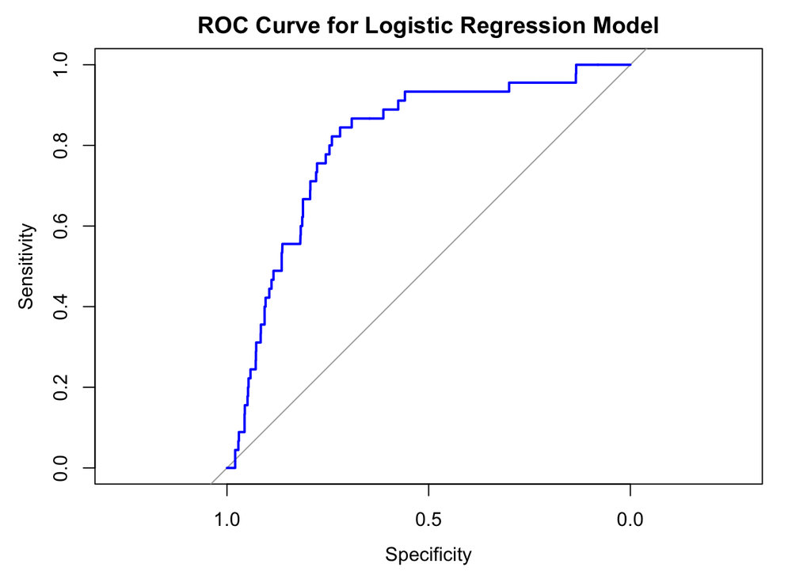

```r
library(pROC)
pred_probs <- predict(logit_model, newdata = test_data, type = "prob")
roc_curve <- roc(test_data$target, pred_probs[,2])
plot(roc_curve, col="blue", lwd=2, main="ROC Curve for Logistic Regression Model")
```

```r
auc(roc_curve)
```

```
Area under the curve: 0.8074
```

*Explain.*

> The ROC curve visualizes the trade-off between true positive rate/sensitivity and false positive rate at different classification thresholds. A model with a curve closer to the top-left corner and the area under the curve being close to 1 is considered a strong classifier.